# Optimal Treatment Analysis

## Outcome Variable

**Outcome Variable:** haz

## Predictor Variables

**Intervention Variable:** hfoodsec

**Adjustment Set:**

- arm
- sex
- W_mage
- meducyrs
- feducyrs
- hhwealth_quart
- vagbrth
- W_nrooms
- W_nchldlt5
- brthmon
- W_parity
- impfloor
- impsan
- safeh20
- delta_W_mage
- delta_meducyrs
- delta_feducyrs
- delta_hhwealth_quart
- delta_vagbrth
- delta_W_nrooms
- delta_W_nchldlt5
- delta_brthmon
- delta_W_parity
- delta_impfloor
- delta_impsan
- delta_safeh20

## Stratifying Variables

The analysis was stratified on these variable(s):

- agecat
- studyid
- country

## Data Summary

| agecat | studyid | country | hfoodsec | n_cell | n |
| --- | --- | --- | --- | --- | --- |
| Birth | GMS-Nepal | NEPAL | Food Secure | 477 | 672 |
| Birth | GMS-Nepal | NEPAL | Mildly Food Insecure | 106 | 672 |
| Birth | GMS-Nepal | NEPAL | Food Insecure | 89 | 672 |
| Birth | JiVitA-3 | BANGLADESH | Food Secure | 6951 | 14364 |
| Birth | JiVitA-3 | BANGLADESH | Mildly Food Insecure | 4877 | 14364 |
| Birth | JiVitA-3 | BANGLADESH | Food Insecure | 2536 | 14364 |
| Birth | JiVitA-4 | BANGLADESH | Food Secure | 1433 | 2810 |
| Birth | JiVitA-4 | BANGLADESH | Mildly Food Insecure | 1018 | 2810 |
| Birth | JiVitA-4 | BANGLADESH | Food Insecure | 359 | 2810 |
| Birth | MAL-ED | BANGLADESH | Food Secure | 144 | 172 |
| Birth | MAL-ED | BANGLADESH | Mildly Food Insecure | 4 | 172 |
| Birth | MAL-ED | BANGLADESH | Food Insecure | 24 | 172 |
| Birth | MAL-ED | BRAZIL | Food Secure | 0 | 28 |
| Birth | MAL-ED | BRAZIL | Mildly Food Insecure | 4 | 28 |
| Birth | MAL-ED | BRAZIL | Food Insecure | 24 | 28 |
| Birth | MAL-ED | INDIA | Food Secure | 34 | 37 |
| Birth | MAL-ED | INDIA | Mildly Food Insecure | 1 | 37 |
| Birth | MAL-ED | INDIA | Food Insecure | 2 | 37 |
| Birth | MAL-ED | NEPAL | Food Secure | 10 | 14 |
| Birth | MAL-ED | NEPAL | Mildly Food Insecure | 1 | 14 |
| Birth | MAL-ED | NEPAL | Food Insecure | 3 | 14 |
| Birth | MAL-ED | PERU | Food Secure | 24 | 91 |
| Birth | MAL-ED | PERU | Mildly Food Insecure | 23 | 91 |
| Birth | MAL-ED | PERU | Food Insecure | 44 | 91 |
| Birth | MAL-ED | SOUTH AFRICA | Food Secure | 45 | 88 |
| Birth | MAL-ED | SOUTH AFRICA | Mildly Food Insecure | 9 | 88 |
| Birth | MAL-ED | SOUTH AFRICA | Food Insecure | 34 | 88 |
| Birth | NIH-Birth | BANGLADESH | Food Secure | 90 | 608 |
| Birth | NIH-Birth | BANGLADESH | Mildly Food Insecure | 478 | 608 |
| Birth | NIH-Birth | BANGLADESH | Food Insecure | 40 | 608 |

[output cut: 69 more lines]

The following strata were considered:

- agecat: 24 months, studyid: GMS-Nepal, country: NEPAL
- agecat: 24 months, studyid: JiVitA-3, country: BANGLADESH
- agecat: 24 months, studyid: JiVitA-4, country: BANGLADESH
- agecat: 24 months, studyid: MAL-ED, country: BANGLADESH
- agecat: 24 months, studyid: MAL-ED, country: BRAZIL
- agecat: 24 months, studyid: MAL-ED, country: INDIA
- agecat: 24 months, studyid: MAL-ED, country: NEPAL
- agecat: 24 months, studyid: MAL-ED, country: PERU
- agecat: 24 months, studyid: MAL-ED, country: SOUTH AFRICA
- agecat: 24 months, studyid: NIH-Birth, country: BANGLADESH
- agecat: 24 months, studyid: NIH-Crypto, country: BANGLADESH
- agecat: 6 months, studyid: GMS-Nepal, country: NEPAL
- agecat: 6 months, studyid: JiVitA-3, country: BANGLADESH
- agecat: 6 months, studyid: JiVitA-4, country: BANGLADESH
- agecat: 6 months, studyid: MAL-ED, country: BANGLADESH
- agecat: 6 months, studyid: MAL-ED, country: BRAZIL
- agecat: 6 months, studyid: MAL-ED, country: INDIA
- agecat: 6 months, studyid: MAL-ED, country: NEPAL
- agecat: 6 months, studyid: MAL-ED, country: PERU
- agecat: 6 months, studyid: MAL-ED, country: SOUTH AFRICA
- agecat: 6 months, studyid: NIH-Birth, country: BANGLADESH
- agecat: 6 months, studyid: NIH-Crypto, country: BANGLADESH
- agecat: Birth, studyid: GMS-Nepal, country: NEPAL
- agecat: Birth, studyid: JiVitA-3, country: BANGLADESH
- agecat: Birth, studyid: JiVitA-4, country: BANGLADESH
- agecat: Birth, studyid: MAL-ED, country: BANGLADESH
- agecat: Birth, studyid: MAL-ED, country: BRAZIL
- agecat: Birth, studyid: MAL-ED, country: INDIA
- agecat: Birth, studyid: MAL-ED, country: NEPAL
- agecat: Birth, studyid: MAL-ED, country: PERU
- agecat: Birth, studyid: MAL-ED, country: SOUTH AFRICA
- agecat: Birth, studyid: NIH-Birth, country: BANGLADESH
- agecat: Birth, studyid: NIH-Crypto, country: BANGLADESH

### Dropped Strata

Some strata were dropped due to rare outcomes:

- agecat: Birth, studyid: MAL-ED, country: BANGLADESH
- agecat: Birth, studyid: MAL-ED, country: BRAZIL
- agecat: Birth, studyid: MAL-ED, country: INDIA
- agecat: Birth, studyid: MAL-ED, country: NEPAL
- agecat: 6 months, studyid: MAL-ED, country: BANGLADESH
- agecat: 6 months, studyid: MAL-ED, country: BRAZIL
- agecat: 24 months, studyid: MAL-ED, country: BANGLADESH
- agecat: 24 months, studyid: MAL-ED, country: BRAZIL

## Methods Detail

We’re interested in the causal parameters $E[Y_a]$ for all values of $a \in \mathcal{A}$. These parameters represent the mean outcome if, possibly contrary to fact, we intervened to set all units to have $A=a$. Under the randomization and positivity assumptions, these are identified by the statistical parameters $\psi_a=E_W[E_{Y|A,W}(Y|A=a,W)]$. In addition, we’re interested in the mean of $Y$, $E[Y]$ under no intervention (the observed mean). We will estimate these parameters by using SuperLearner to fit the relevant likelihood factors – $E_{Y|A,W}(Y|A=a,W)$ and $p(A=a|W)$, and then updating our likelihood fit using a joint TMLE.

For unadjusted analyses ($W=\{\}$), initial likelihoods were estimated using Lrnr_glm to estimate the simple $E(Y|A)$ and Lrnr_mean to estimate $p(A)$. For adjusted analyses, a small library containing Lrnr_glmnet, Lrnr_xgboost, and Lrnr_mean was used.

# Results Detail

## Results Plots

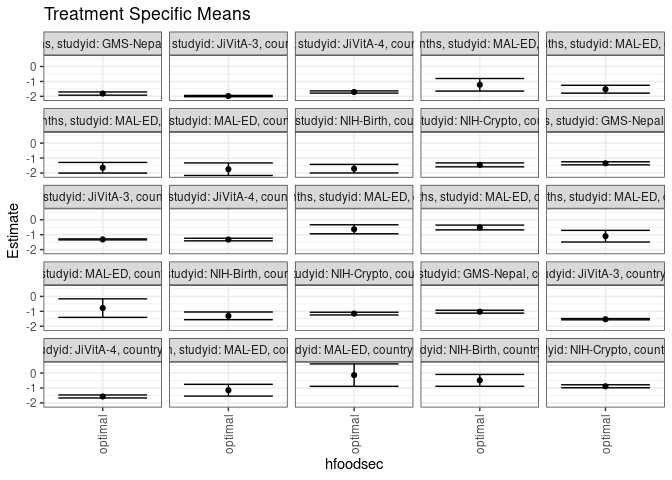

## Results Table

### Parameter: TSM

| agecat | studyid | country | intervention_level | baseline_level | estimate | ci_lower | ci_upper |
| --- | --- | --- | --- | --- | --- | --- | --- |
| Birth | GMS-Nepal | NEPAL | optimal | observed | -1.0244831 | -1.1210434 | -0.9279228 |
| Birth | JiVitA-3 | BANGLADESH | optimal | observed | -1.5293736 | -1.5718822 | -1.4868650 |
| Birth | JiVitA-4 | BANGLADESH | optimal | observed | -1.5706446 | -1.6708294 | -1.4704599 |
| Birth | MAL-ED | PERU | optimal | observed | -1.1519720 | -1.5462242 | -0.7577197 |
| Birth | MAL-ED | SOUTH AFRICA | optimal | observed | -0.1404073 | -0.8922192 | 0.6114045 |
| Birth | NIH-Birth | BANGLADESH | optimal | observed | -0.4914304 | -0.8886552 | -0.0942056 |
| Birth | NIH-Crypto | BANGLADESH | optimal | observed | -0.8870332 | -0.9877173 | -0.7863491 |
| 6 months | GMS-Nepal | NEPAL | optimal | observed | -1.3527388 | -1.4537709 | -1.2517066 |
| 6 months | JiVitA-3 | BANGLADESH | optimal | observed | -1.3173203 | -1.3507576 | -1.2838829 |
| 6 months | JiVitA-4 | BANGLADESH | optimal | observed | -1.3248090 | -1.4105150 | -1.2391031 |
| 6 months | MAL-ED | INDIA | optimal | observed | -0.6378582 | -0.9399057 | -0.3358107 |
| 6 months | MAL-ED | NEPAL | optimal | observed | -0.5168153 | -0.6765613 | -0.3570694 |
| 6 months | MAL-ED | PERU | optimal | observed | -1.1005919 | -1.4912745 | -0.7099093 |
| 6 months | MAL-ED | SOUTH AFRICA | optimal | observed | -0.7844561 | -1.4056460 | -0.1632662 |
| 6 months | NIH-Birth | BANGLADESH | optimal | observed | -1.3027283 | -1.5595474 | -1.0459093 |
| 6 months | NIH-Crypto | BANGLADESH | optimal | observed | -1.1535187 | -1.2459995 | -1.0610380 |
| 24 months | GMS-Nepal | NEPAL | optimal | observed | -1.8125780 | -1.9196060 | -1.7055500 |
| 24 months | JiVitA-3 | BANGLADESH | optimal | observed | -1.9810443 | -2.0218649 | -1.9402238 |
| 24 months | JiVitA-4 | BANGLADESH | optimal | observed | -1.7088095 | -1.7829784 | -1.6346406 |
| 24 months | MAL-ED | INDIA | optimal | observed | -1.2249168 | -1.6458165 | -0.8040170 |
| 24 months | MAL-ED | NEPAL | optimal | observed | -1.5219404 | -1.7849192 | -1.2589615 |
| 24 months | MAL-ED | PERU | optimal | observed | -1.6489285 | -2.0057164 | -1.2921407 |
| 24 months | MAL-ED | SOUTH AFRICA | optimal | observed | -1.7494206 | -2.1689036 | -1.3299376 |
| 24 months | NIH-Birth | BANGLADESH | optimal | observed | -1.7127032 | -2.0002865 | -1.4251200 |
| 24 months | NIH-Crypto | BANGLADESH | optimal | observed | -1.4561726 | -1.5884279 | -1.3239173 |

### Parameter: E(Y)

| agecat | studyid | country | intervention_level | baseline_level | estimate | ci_lower | ci_upper |
| --- | --- | --- | --- | --- | --- | --- | --- |
| Birth | GMS-Nepal | NEPAL | observed | observed | -1.0791964 | -1.1604792 | -0.9979137 |
| Birth | JiVitA-3 | BANGLADESH | observed | observed | -1.5375132 | -1.5596692 | -1.5153573 |
| Birth | JiVitA-4 | BANGLADESH | observed | observed | -1.5248719 | -1.5743851 | -1.4753587 |
| Birth | MAL-ED | PERU | observed | observed | -0.9490110 | -1.1400314 | -0.7579906 |
| Birth | MAL-ED | SOUTH AFRICA | observed | observed | -0.5503409 | -0.7616444 | -0.3390374 |
| Birth | NIH-Birth | BANGLADESH | observed | observed | -0.9310197 | -1.0197391 | -0.8423003 |
| Birth | NIH-Crypto | BANGLADESH | observed | observed | -0.9094945 | -0.9809370 | -0.8380521 |
| 6 months | GMS-Nepal | NEPAL | observed | observed | -1.3421764 | -1.4201083 | -1.2642445 |
| 6 months | JiVitA-3 | BANGLADESH | observed | observed | -1.3131326 | -1.3362851 | -1.2899801 |
| 6 months | JiVitA-4 | BANGLADESH | observed | observed | -1.3446891 | -1.3822219 | -1.3071564 |
| 6 months | MAL-ED | INDIA | observed | observed | -1.2019969 | -1.3256948 | -1.0782989 |
| 6 months | MAL-ED | NEPAL | observed | observed | -0.6262760 | -0.7758267 | -0.4767254 |
| 6 months | MAL-ED | PERU | observed | observed | -1.3783784 | -1.5611768 | -1.1955799 |
| 6 months | MAL-ED | SOUTH AFRICA | observed | observed | -1.0539254 | -1.1902766 | -0.9175743 |
| 6 months | NIH-Birth | BANGLADESH | observed | observed | -1.4073821 | -1.4960598 | -1.3187043 |
| 6 months | NIH-Crypto | BANGLADESH | observed | observed | -1.1986783 | -1.2700937 | -1.1272630 |
| 24 months | GMS-Nepal | NEPAL | observed | observed | -1.8758368 | -1.9623349 | -1.7893388 |
| 24 months | JiVitA-3 | BANGLADESH | observed | observed | -2.0099416 | -2.0377955 | -1.9820876 |
| 24 months | JiVitA-4 | BANGLADESH | observed | observed | -1.7801485 | -1.8158427 | -1.7444543 |
| 24 months | MAL-ED | INDIA | observed | observed | -1.8868396 | -2.0164954 | -1.7571839 |
| 24 months | MAL-ED | NEPAL | observed | observed | -1.4092187 | -1.5701249 | -1.2483126 |
| 24 months | MAL-ED | PERU | observed | observed | -1.7783956 | -1.9536701 | -1.6031212 |
| 24 months | MAL-ED | SOUTH AFRICA | observed | observed | -1.6331323 | -1.7704624 | -1.4958022 |
| 24 months | NIH-Birth | BANGLADESH | observed | observed | -2.2190579 | -2.3217459 | -2.1163699 |
| 24 months | NIH-Crypto | BANGLADESH | observed | observed | -1.4412646 | -1.5249156 | -1.3576135 |

### Parameter: PAR

| agecat | studyid | country | intervention_level | baseline_level | estimate | ci_lower | ci_upper |
| --- | --- | --- | --- | --- | --- | --- | --- |
| Birth | GMS-Nepal | NEPAL | optimal | observed | -0.0547133 | -0.1120236 | 0.0025970 |
| Birth | JiVitA-3 | BANGLADESH | optimal | observed | -0.0081396 | -0.0437115 | 0.0274323 |
| Birth | JiVitA-4 | BANGLADESH | optimal | observed | 0.0457728 | -0.0393341 | 0.1308796 |
| Birth | MAL-ED | PERU | optimal | observed | 0.2029610 | -0.1326336 | 0.5385556 |
| Birth | MAL-ED | SOUTH AFRICA | optimal | observed | -0.4099336 | -1.1294462 | 0.3095791 |
| Birth | NIH-Birth | BANGLADESH | optimal | observed | -0.4395893 | -0.8177632 | -0.0614155 |
| Birth | NIH-Crypto | BANGLADESH | optimal | observed | -0.0224613 | -0.0941981 | 0.0492755 |
| 6 months | GMS-Nepal | NEPAL | optimal | observed | 0.0105623 | -0.0643866 | 0.0855113 |
| 6 months | JiVitA-3 | BANGLADESH | optimal | observed | 0.0041876 | -0.0204802 | 0.0288555 |
| 6 months | JiVitA-4 | BANGLADESH | optimal | observed | -0.0198801 | -0.1003320 | 0.0605718 |
| 6 months | MAL-ED | INDIA | optimal | observed | -0.5641386 | -0.8844645 | -0.2438127 |
| 6 months | MAL-ED | NEPAL | optimal | observed | -0.1094607 | -0.2123796 | -0.0065418 |
| 6 months | MAL-ED | PERU | optimal | observed | -0.2777865 | -0.6115031 | 0.0559301 |
| 6 months | MAL-ED | SOUTH AFRICA | optimal | observed | -0.2694693 | -0.8606885 | 0.3217498 |
| 6 months | NIH-Birth | BANGLADESH | optimal | observed | -0.1046537 | -0.3402826 | 0.1309751 |
| 6 months | NIH-Crypto | BANGLADESH | optimal | observed | -0.0451596 | -0.1047278 | 0.0144087 |
| 24 months | GMS-Nepal | NEPAL | optimal | observed | -0.0632588 | -0.1251667 | -0.0013509 |
| 24 months | JiVitA-3 | BANGLADESH | optimal | observed | -0.0288972 | -0.0584101 | 0.0006156 |
| 24 months | JiVitA-4 | BANGLADESH | optimal | observed | -0.0713390 | -0.1362365 | -0.0064416 |
| 24 months | MAL-ED | INDIA | optimal | observed | -0.6619228 | -1.0932177 | -0.2306280 |
| 24 months | MAL-ED | NEPAL | optimal | observed | 0.1127216 | -0.1242918 | 0.3497350 |
| 24 months | MAL-ED | PERU | optimal | observed | -0.1294671 | -0.4463243 | 0.1873901 |
| 24 months | MAL-ED | SOUTH AFRICA | optimal | observed | 0.1162883 | -0.2604438 | 0.4930204 |
| 24 months | NIH-Birth | BANGLADESH | optimal | observed | -0.5063546 | -0.7705209 | -0.2421884 |
| 24 months | NIH-Crypto | BANGLADESH | optimal | observed | 0.0149080 | -0.0830273 | 0.1128433 |